# Introduction to Python

# 13 Built-in Functions & Tools

## The import statement

When you create a Python program, you might split your code up into different files. These files are known as modules. We touched on this in the Frameworks, Modules And Libraries unit. Python allows you to import entire modules or individual functions, classes or variables into other modules.

Python has built-in modules that we can import from as well. We do this with the `import` statement.

[figure not shown]

In the example, we have a `division` function in a `divide.py` module. In `main.py`, we have imported the `division` function from the `divide.py` module, which allows us to use the `division` function using the `division()` syntax directly. However, we do not have access to the `mod` function unless we also add a `from divide import mod` statement in `main.py`.

To avoid this, we could have used `import divide` to import the whole module and then used `divide.division()` or `divide.mod()` directly.

`divide.py`

```
def division(numerator, denominator):
    result = numerator / denominator
    return result

def mod(numerator, denominator):
    result = numerator % denominator
    return result
```

`main.py`

```
from divide import division

print(division(4, 2))
```

## Math Module

Python has a plethora of built-in libraries for everyday tasks. One of the most useful is `Math`. If you need to do a calculation in your code, then it is a good idea to `import` from this library, rather than reinventing the wheel. As math is a built-in library it comes with Python, and there is no need to install it separately.

Most frequently used elements from `Math` module:

| Method | Description |
| --- | --- |
| ceil() | Rounds a number up to the nearest integer |
| comb() | Returns the number of ways to choose k items from n items without repetition and order |
| dist() | Returns the Euclidean distance between two points (p and q), where p and q are the coordinates of that point |
| exp() | Returns E raised to the power of x |
| fabs() | Returns the absolute value of a number |
| factorial() | Returns the factorial of a number |
| floor() | Rounds a number down to the nearest integer |
| fmod() | Returns the remainder of x/y |
| fsum() | Returns the sum of all items in any iterable (tuples, arrays, lists, etc.) |
| isnan() | Checks whether a value is NaN (not a number) or not |
| perm() | Returns the number of ways to choose k items from n items with order and without repetition |
| pow() | Returns the value of x to the power of y |
| prod() | Returns the product of all the elements in an iterable |
| remainder() | Returns the closest value that can make numerator completely divisible by the denominator |
| sqrt() | Returns the square root of a number |
| trunc() | Returns the truncated integer parts of a number |

Math Constants

| Constant | Description |
| --- | --- |
| e | Returns Euler's number (2.7182...) |
| inf | Returns a floating-point positive infinity |
| nan | Returns a floating-point NaN (Not a Number) value |
| pi | Returns PI (3.1415...) |
| tau | Returns tau (6.2831...) |

```python
import math

print(math.pi)

print(math.sqrt(4))
```

```
3.141592653589793
2.0
```

#### Additional Perspectives From People We Like

A full list of the mathematical functions available can be found in the [official python documentation](https://docs.python.org/3/library/math.html).

## DateTime Module

Dates and times can be tricky to work with, when coding. This is due to the differences in how a user may input a date. Also, you have to take into account whether the program has access to timezone information and what operating system is used by the computer on which you are running the program. There is no date data type in Python. The built-in datetime library allows you to manipulate dates and times.

[figure not shown]

In the example, we have displayed the local current date and time where this code is running. The date contains a year, month, day, hour, minute, second and microsecond. The library contains methods to access that data. We have obtained the year and printed it to the console. A common usage of the `datetime` library is to get a readable string from the `datetime` object. There is a method called `strftime()` that takes a parameter format to return the string as you would like to display it to your user. In the first part of the runnable example we have shown the day of the week.

We can also access date information with python using `datetime` instance methods such as `date()` and `time()`. You can see these in action in the second part of the example below.

```python
from datetime import datetime

x = datetime.now()
print(x)
```

```
2021-04-23 09:22:30.041620
```

```python
x.year
```

```
2021
```

```python
x.strftime("%A")
```

```
'Friday'
```

```python
str(datetime.now().date())
```

```
'2021-04-23'
```

```python
str(datetime.now().time())
```

```
'09:22:30.110629'
```

#### Additional Perspectives From People We Like

There are a large number of date and time objects as well as methods that can be applied to them. You can find a comprehensive list of them on the [official Python documentation](https://docs.python.org/3/library/datetime.html).

## OS Library

The `os` library provides a way of using the operating system (os) functionality. The operating system is the software that interfaces between the hardware and user on a computer. Common operating systems would be Windows, macOS, Linux or iOS.

[figure not shown]

A frequent use for this would be accessing the environment variables. Every computer has a set of environment variables listing information on how the machine is set up. Examples of this would be the directory structure of the home directory or the computers users profile.

In the runnable example, we use the get current working directory function `getcwd()` to find the directory in which the python file is located.

```python
import os
print(os.getcwd())
```

```
C:\Users\ruszk\Google Drive\Learning\Python
```

We can also list the files or directories with `listdir()` within a directory.

```python
print(os.listdir('./img/'))
```

```
['0+none.png', 'animal-class.png', 'arithmetic+operators.png', 'assignment+operators.png', 'book.txt', 'break+continue+pass.png', 'bug.png', 'car-class.png', 'class+method.png', 'class+mixin.png', 'class-properties.png', 'comparison+operators.png', 'containment.png', 'converting+between+data+types.p…
```

#### Additional Perspectives From People We Like

There are a great number of commands from the operating system that you can run from the python code. For a comprehensive list of commands in the `os` library check out the [official python documentation](https://docs.python.org/3/library/os.html).

### `os.path` Module

Within the `os` library, there is a module named `path`. This allows you to manipulate the pathnames on the operating system of the computer on which you are running the code. This is useful when saving data to the local operating system. If you remember back to the CSS Essentials lessons, getting the correct relative or absolute pathname was vital in linking files. The `os.path()` methods allow you to dynamically create path names so you can connect to files on the operating system and save files where you intend to.

[figure not shown]

In the example, we have taken the absolute path and joined it with the current working directory. This uses the `join()` method of the `path` module. There is also a `split()` method allowing you to split a path. In this case, we have split the filename from the pathname and assigned them to a tuple. The `splitext()` method allows you to split the module name from its file extension.

```python
import os
# This is how you would join two paths in your code
print(os.path.join('/home/runner/', 'os'))

path = "/home/runner/os/main.py"
# Splits the path into a pair (head, tail) where the tail is the end of the pathname
# The tail is after the / and the head is the pathname up to that point
(dirname, filename) = os.path.split(path)
print(f'The directory path is {dirname}')
print(f'The filename is {filename}')
# Splits the filename into a pair (root, ext)
# The root is before the dot and the ext contains the dot with the suffix after it
(module, extension) = os.path.splitext(filename)
print(f'The module is {module}')
print(f'Its file suffix is {extension}')
```

```
/home/runner/os
The directory path is /home/runner/os
The filename is main.py
The module is main
Its file suffix is .py
```

#### Additional Perspectives From People We Like

There are many more methods in `os.path` which can be found in the [official python documentation](https://docs.python.org/3/library/os.path.html).

## `sys` Library

Python has an inbuilt interpreter. Python code does not need to be compiled. We can try out code in the Python interpreter. The `sys` library provides us with information about the constants, functions and methods of the interpreter. Up till now, we have seen the output of our code and errors in the terminal. This is the standard output for a command-line program. The `sys` library allows us to change that default location. For example, you could send error messages to a text file.

[figure not shown]

In the image, you can see file objects in the `sys` library. The `stdin` object is interactive input. The `stdout` object is the print or expression outputs that go to the terminal. The `stderr` object is any error messages.

```python
import sys
sys.getrecursionlimit()
```

```
3000
```

```python
sys.version
```

```
'3.8.5 (default, Sep  3 2020, 21:29:08) [MSC v.1916 64 bit (AMD64)]'
```

```python
sys.platform
```

```
'win32'
```

```python
sys.path
```

```
['C:\\Users\\ruszk\\Google Drive\\Learning\\Python',
 'C:\\ProgramData\\Anaconda3\\python38.zip',
 'C:\\ProgramData\\Anaconda3\\DLLs',
 'C:\\ProgramData\\Anaconda3\\lib',
 'C:\\ProgramData\\Anaconda3',
 '',
 'C:\\Users\\ruszk\\AppData\\Roaming\\Python\\Python38\\site-packages',
 'C:\\ProgramData\\Anaconda3\\lib\\site-packages',
 'C:\\ProgramData\\Anaconda3\\lib\\site-packages\\win32',
 'C:\\ProgramData\\Anaconda3\\lib\\site-packages\\win32\\lib',
 'C:\\ProgramData\\Anaconda3\\lib\\site-packages\\Pythonwin',
 'C:\\ProgramData\\Anaconda3\\lib\\site-packages\\IPython\\extensions',
 'C:\\Users\\ruszk\\.ipython']
```

In the runnable example, we use the `sys.stderr` to redirect the standard error stream from the terminal to a text file. We then provoke an error message by dividing by zero. If you run the code, you will see the error message saved to an `errors.txt` file. In the loops lessons, you were warned to avoid infinite loops as this will crash your computer. In reality, there is an upper limit set for the depth of the Python stack. You will receive an error message well below infinity! This value is settable, and you can find what value runnable example has set.

```
import sys

save_standard_error = sys.stderr
with open("errors.txt","w") as error_file:
    sys.stderr = error_file

    x = 10 / 0

    # return to normal:
    sys.stderr = save_standard_error
```

`errors.txt`

```
Traceback (most recent call last):
  File "main.py", line 6, in <module>
    x = 10 / 0
ZeroDivisionError: division by zero
```

#### Additional Perspectives From People We Like

All the additional available sys data can be seen at the [official Python documentation](https://docs.python.org/3.0/library/sys.html).

## `random` Library

An everyday computing problem is making a random choice. Computers are not good at being random. The random library generates pseudo-random numbers that are suitable for most purposes. You can use these for games or simple statistical checks.

[figure not shown]

In the runnable example, you can see how you would generate a random float, integer or choice. You can also shuffle existing data structures.

```python
import random

print(f'A random float between 0 & 1.0: {random.random()}')
print(f'A random int between 0 & 10: {random.randrange(11)}')
print('A random choice from a list: ' + random.choice(['paper', 'scissors', 'rock']))
deck = ['hearts', 'diamonds', 'spades', 'clubs']
random.shuffle(deck)
print(deck)
```

```
A random float between 0 & 1.0: 0.4913461104112826
A random int between 0 & 10: 9
A random choice from a list: paper
['spades', 'hearts', 'clubs', 'diamonds']
```

#### Additional Perspectives From People We Like

All the additional available random methods can be seen at the [official Python documentation](https://docs.python.org/3/library/random.html).

## Third party Libraries

In addition to the built-in libraries, as Python is open source, anyone can create software and share it with the community. A library is a collection of modules that have some common functionality. There is a Python Package Index (pypi.org) where these open source projects are shared.

[figure not shown]

In the example, we are using a third-party library named `numpy`. It is a widely used library for scientific computing. We can give the package name an alias (`np` in this case), so we don’t have to type it out each time. Numpy extends the abilities of Python into scientific computing. Here we are creating a simple one-dimensional array. If you were trying this on your computer, you would have to install `numpy` locally as it is a third-party library rather than a built-in library installed with Python.

```python
import numpy as np
a = np.array([1, 2, 3])
print(a)
```

```
[1 2 3]
```

```python
from dateutil import parser
log_line = 'INFO 2020-07-03T23:27:51 Shutdown complete.'
timestamp = parser.parse(log_line, fuzzy=True)
print(timestamp)
```

```
2020-07-03 23:27:51
```

# 14 Scientific Python

Scientific python refers to a large collection of libraries that can be used with python for a range of numerical and scientific computing tasks. Most of these already come with the Anaconda distribution, but if you have only installed the basic python distribution you may need to add the additional libraries (see [scipy](https://www.scipy.org/)).

Here we just scratch the surface of what is available. This should be enough to get you started with some of the most commonly used modules, but for any specific project that you have, it is worth doing some searching online to see what is already availalbe as part of the this ecosystem.

### Matrices

Dealing with vectors and matrices efficiently requires the **numpy** library. For the sake of brevity we will import this with a shorter name:

```python
import numpy as np
```

The numpy supports arrays and matrices with many of the features that would be familiar to matlab users. See here quick summary of [numpy for matlab users](https://docs.scipy.org/doc/numpy-dev/user/numpy-for-matlab-users.html).

Appart from the convenience, the numpy methods are also much faster at performing operations on matrices or arrays than performing arithmetic with numbers stored in lists.

```python
x = np.array([1,2,3,4,5])
y = np.array([2*i for i in x])
x+y # element wise addition
```

```
array([ 3,  6,  9, 12, 15])
```

```python
X = x[:4].reshape(2,2) # turn into a matrix/table
2*X # multiply by a scalar
```

```
array([[2, 4],
       [6, 8]])
```

However watch out: array is not quite a matrix. For proper matrix operations you need to use the matrix type. Unlike **array**s that can have any number of dimensions, matrices are limited to 2 dimension. However matrix multiplication does what you would expect from a linear algebra point of view, rather than an element-wise multiplication:

```python
Y = np.matrix(X)
print("X=Y=\n",Y)
print("array X*X=\n",X*X,'\nmatrix Y*Y=\n',Y*Y)
```

```
X=Y=
 [[1 2]
 [3 4]]
array X*X=
 [[ 1  4]
 [ 9 16]]
matrix Y*Y=
 [[ 7 10]
 [15 22]]
```

Much more information on how to use numpy is available at [quick start tutorial](https://docs.scipy.org/doc/numpy-dev/user/quickstart.html)

### Plotting

There are lots of configuration options for the **matplotlib** library that we are using here. For more information see [http://matplotlib.org/users/beginner.html]

To get started we need the import the required libraries.

```python
import numpy as np
import matplotlib.pyplot as plt
```

Now we can try something simple. The most basic plot command simply takes a list of numbers to be plotted at integer positions.

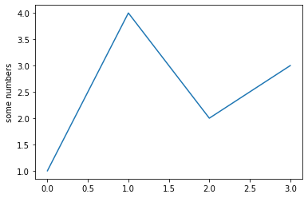

```python
plt.plot([1,4,2,3])
plt.ylabel('some numbers')
plt.show() # optional
```

**Aside:** In this notebook the examples use the `pyplot` module which by default has a single global `Figure` and associated `Axes` object. This can be convenient but gets confusing if you want to create a whole series of plots. For such more advanced use you would want to do something like:

```
fig, ax = plt.subplots(figsize=(8, 8))
```

Then replace commands like `plt.plot` with `fig.plot` to crate a plot for this specific figure object. You can get access to the "global" figure object with `plt.gcf()` (get current figure function) and similarly `plt.gca()` gets the axes object.

#### Alternative plot types

As a slightly more complicated example, here is some CSV format data that we parse and plot as points (scatter plot). In this version of the plot command the x and y coordinates are given as separate lists followed by a formatting string "r*" (red asterix symbols)

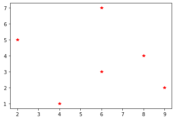

```python
data="""
4,1
2,5
9,2
6,3
6,7
8,4
"""
# crude parsing of CSV data - use csv module for reading csv files
xy = [ [float(i) for i in line.strip().split(",")]
      for line in data.split()]
x = [ pt[0] for pt in xy]
y = [ pt[1] for pt in xy]
plt.plot(x,y,"r*")
plt.show()
```

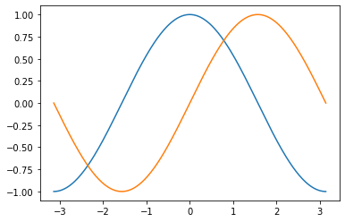

```python
# A slightly more complicated plot with the help of numpy
X = np.linspace(-np.pi, np.pi, 256, endpoint=True)
C, S = np.cos(X), np.sin(X)  # create arrays of function values for each X value

plt.plot(X, C)
plt.plot(X, S)

plt.show()
```

Annotating plots can be done with methods like **text()** to place a label and **annotate()**. For example:

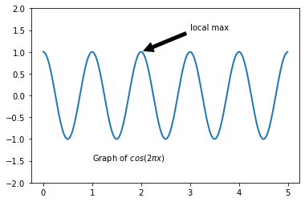

```python
t = np.arange(0.0, 5.0, 0.01)
line, = plt.plot(t, np.cos(2*np.pi*t), lw=2)
plt.annotate('local max', xy=(2, 1), xytext=(3, 1.5),
            arrowprops=dict(facecolor='black', shrink=0.05),
            )
# text can include basic LaTeX commands - but need to mark
# string as raw (r"") or escape '\' (by using '\\')
plt.text(1,-1.5,r"Graph of $cos(2\pi x)$")
plt.ylim(-2,2)
plt.show()
```

Here is an example of how to create a basic surface contour plot.

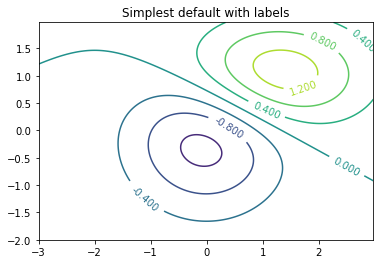

```python
from scipy.stats import * # for multivariate_normal to define our surface
delta = 0.025
x = np.arange(-3.0, 3.0, delta)
y = np.arange(-2.0, 2.0, delta)
X, Y = np.meshgrid(x, y) # define mesh of points
pos = np.empty(X.shape + (2,))
pos[:, :, 0] = X; pos[:, :, 1] = Y
rv1 = multivariate_normal([0, 0], [[1.0, 0.0], [0.0, 1.0]])
rv2 = multivariate_normal([1, 1], [[1.5, 0.0], [0.0, 0.5]])
#Z1 = bivariate_normal(X, Y, 1.0, 1.0, 0.0, 0.0)
#Z2 = bivariate_normal(X, Y, 1.5, 0.5, 1, 1)
Z1 = rv1.pdf(pos)
Z2 = rv2.pdf(pos)
Z = 10.0 * (Z2 - Z1) # difference of Gaussians

# Create a simple contour plot with labels using default colors.  The
# inline argument to clabel will control whether the labels are draw
# over the line segments of the contour, removing the lines beneath
# the label
plt.figure()
CS = plt.contour(X, Y, Z)
plt.clabel(CS, inline=1, fontsize=10)
plt.title('Simplest default with labels')
plt.show()
```

#### Saving Plots

If you want to use your plot in a paper or similar there a few differnt options:

1. You can copy and paste the picture out of the browser window if you are using notebooks
2. You can specifically save the picture to a file in a range of formats simply using the `savefig()` method on plots. The format is guessed based on the filename extension

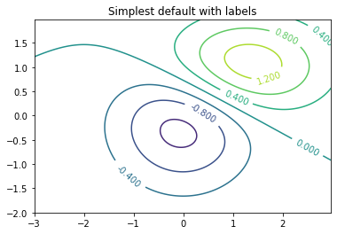

```python
CS = plt.contour(X, Y, Z)
plt.clabel(CS, inline=1, fontsize=10)
plt.title('Simplest default with labels')
# uncomment the following lines to make it work
#plt.savefig("surface_ex.png")
#plt.savefig("surface_ex.pdf")
```

Look in the directory containing this notebook and you should find 2 files: `surface_ex.png` and `surface_ex.pdf` that you can download.

The complete list of filetypes supported by matplotlib is:

```python
for ext,description in plt.gcf().canvas.get_supported_filetypes().items():
    print("%s: \t%s" % (ext,description))
```

```
eps: 	Encapsulated Postscript
jpg: 	Joint Photographic Experts Group
jpeg: 	Joint Photographic Experts Group
pdf: 	Portable Document Format
pgf: 	PGF code for LaTeX
png: 	Portable Network Graphics
ps: 	Postscript
raw: 	Raw RGBA bitmap
rgba: 	Raw RGBA bitmap
svg: 	Scalable Vector Graphics
svgz: 	Scalable Vector Graphics
tif: 	Tagged Image File Format
tiff: 	Tagged Image File Format
```